# RIBO-Seq Workflow Template_test

Author: Daniela Cassol (danielac@ucr.edu) and Thomas Girke (thomas.girke@ucr.edu)

Last update: 14 April, 2022

#### Package

systemPipeR 2.1.21

# 1 Introduction

Ribo-Seq and polyRibo-Seq are a specific form of RNA-Seq gene expression experiments utilizing mRNA subpopulations directly bound to ribosomes. Compared to standard RNA-Seq, their readout of gene expression provides a better approximation of downstream protein abundance profiles due to their close association with translational processes. The most important difference among the two is that polyRibo-Seq utilizes polyribosomal RNA for sequencing, whereas Ribo-Seq is a footprinting approach restricted to sequencing RNA fragments protected by ribosomes (Ingolia et al. 2009; Aspden et al. 2014; Juntawong et al. 2015).

The workflow presented in this vignette contains most of the data analysis steps described by (Juntawong et al. 2014) including functionalities useful for processing both polyRibo-Seq and Ribo-Seq experiments. To improve re-usability and adapt to recent changes of software versions (*e.g.* R, Bioconductor and short read aligners), the code has been optimized accordingly. Thus, the results obtained with the updated workflow are expected to be similar but not necessarily identical with the published results described in the original paper.

Relevant analysis steps of this workflow include read preprocessing, read alignments against a reference genome, counting of reads overlapping with a wide range of genomic features (*e.g.* CDSs, UTRs, uORFs, rRNAs, etc.), differential gene expression and differential ribosome binding analyses, as well as a variety of genome-wide summary plots for visualizing RNA expression trends. Functions are provided for evaluating the quality of Ribo-seq data, for identifying novel expressed regions in the genomes, and for gaining insights into gene regulation at the post-transcriptional and translational levels. For example, the functions `genFeatures` and `featuretypeCounts` can be used to quantify the expression output for all feature types included in a genome annotation (`e.g.` genes, introns, exons, miRNAs, intergenic regions, etc.). To determine the approximate read length of ribosome footprints in Ribo-Seq experiments, these feature type counts can be obtained and plotted for specific read lengths separately. Typically, the most abundant read length obtained for translated features corresponds to the approximate footprint length occupied by the ribosomes of a given organism group. Based on the results from several Ribo-Seq studies, these ribosome footprints are typically ~30 nucleotides long (Ingolia, Lareau, and Weissman 2011; Ingolia et al. 2009; Juntawong et al. 2014). However, their length can vary by several nucleotides depending upon the optimization of the RNA digestion step and various factors associated with translational regulation. For quality control purposes of Ribo-Seq experiments it is also useful to monitor the abundance of reads mapping to rRNA genes due to the high rRNA content of ribosomes. This information can be generated with the `featuretypeCounts` function described above.

Coverage trends along transcripts summarized for any number of transcripts can be obtained and plotted with the functions `featureCoverage` and `plotfeatureCoverage`, respectively. Their results allow monitoring of the phasing of ribosome movements along triplets of coding sequences. Commonly, high quality data will display here for the first nucleotide of each codon the highest depth of coverage computed for the 5’ ends of the aligned reads.

Ribo-seq data can also be used to evaluate various aspects of translational control due to ribosome occupancy in upstream open reading frames (uORFs). The latter are frequently present in (or near) 5’ UTRs of transcripts. For this, the function `predORFs` can be used to identify ORFs in the nucleotide sequences of transcripts or their subcomponents such as UTR regions. After scaling the resulting ORF coordinates back to the corresponding genome locations using `scaleRanges`, one can use these novel features (*e.g.* uORFs) for expression analysis routines similar to those employed for pre-existing annotations, such as the exonic regions of genes. For instance, in Ribo-Seq experiments one can use this approach to systematically identify all transcripts occupied by ribosomes in their uORF regions. The binding of ribosomes to uORF regions may indicate a regulatory role in the translation of the downstream main ORFs and/or translation of the uORFs into functionally relevant peptides.

## 1.1 Experimental design

Typically, users want to specify here all information relevant for the analysis of their NGS study. This includes detailed descriptions of FASTQ files, experimental design, reference genome, gene annotations, etc.

# 2 Workflow environment

## 2.1 Load packages and sample data

The `systemPipeR` package needs to be loaded to perform the analysis steps shown in this report (H Backman and Girke 2016). The package allows users to run the entire analysis workflow interactively or with a single command while also generating the corresponding analysis report. For details see `systemPipeR's` main [vignette](http://www.bioconductor.org/packages/devel/bioc/vignettes/systemPipeR/inst/doc/systemPipeR.html).

```r
library(systemPipeR)
```

## 2.2 Generate workflow environment

[*systemPipeRdata*](http://bioconductor.org/packages/release/data/experiment/html/systemPipeRdata.html) package is a helper package to generate a fully populated [*systemPipeR*](http://bioconductor.org/packages/release/bioc/html/systemPipeR.html) workflow environment in the current working directory with a single command. All the instruction for generating the workflow template are provide in the *systemPipeRdata* vignette [here](http://www.bioconductor.org/packages/devel/data/experiment/vignettes/systemPipeRdata/inst/doc/systemPipeRdata.html#1_Introduction).

```r
systemPipeRdata::genWorkenvir(workflow = "riboseq", mydirname = "riboseq")
setwd("riboseq")
```

After building and loading the workflow environment generated by `genWorkenvir` from *systemPipeRdata* all data inputs are stored in a `data/` directory and all analysis results will be written to a separate `results/` directory, while the `systemPipeRIBOseq.Rmd` script and the `targets` file are expected to be located in the parent directory. The R session is expected to run from this parent directory. Additional parameter files are stored under `param/`.

To work with real data, users want to organize their own data similarly and substitute all test data for their own data. To rerun an established workflow on new data, the initial `targets` file along with the corresponding FASTQ files are usually the only inputs the user needs to provide. Please check the initial `targets` file details below.

For more details, please consult the documentation [here](http://www.bioconductor.org/packages/release/bioc/vignettes/systemPipeR/inst/doc/systemPipeR.html). More information about the `targets` files from *systemPipeR* can be found [here](http://www.bioconductor.org/packages/release/bioc/vignettes/systemPipeR/inst/doc/systemPipeR.html#42_Structure_of_initial_targets_data).

## 2.3 Experiment definition provided by `targets` file

The `targets` file defines all FASTQ files and sample comparisons of the analysis workflow.

```r
targetspath <- system.file("extdata", "targetsPE.txt", package = "systemPipeR")
targets <- read.delim(targetspath, comment.char = "#")[, 1:4]
targets
```

```
##                      FileName1                   FileName2
## 1  ./data/SRR446027_1.fastq.gz ./data/SRR446027_2.fastq.gz
## 2  ./data/SRR446028_1.fastq.gz ./data/SRR446028_2.fastq.gz
## 3  ./data/SRR446029_1.fastq.gz ./data/SRR446029_2.fastq.gz
## 4  ./data/SRR446030_1.fastq.gz ./data/SRR446030_2.fastq.gz
## 5  ./data/SRR446031_1.fastq.gz ./data/SRR446031_2.fastq.gz
## 6  ./data/SRR446032_1.fastq.gz ./data/SRR446032_2.fastq.gz
## 7  ./data/SRR446033_1.fastq.gz ./data/SRR446033_2.fastq.gz
## 8  ./data/SRR446034_1.fastq.gz ./data/SRR446034_2.fastq.gz
## 9  ./data/SRR446035_1.fastq.gz ./data/SRR446035_2.fastq.gz
## 10 ./data/SRR446036_1.fastq.gz ./data/SRR446036_2.fastq.gz
## 11 ./data/SRR446037_1.fastq.gz ./data/SRR446037_2.fastq.gz
## 12 ./data/SRR446038_1.fastq.gz ./data/SRR446038_2.fastq.gz
## 13 ./data/SRR446039_1.fastq.gz ./data/SRR446039_2.fastq.gz
## 14 ./data/SRR446040_1.fastq.gz ./data/SRR446040_2.fastq.gz
```

[output cut: 23 more lines]

# 3 Workflow environment

*`systemPipeR`* workflows can be designed and built from start to finish with a single command, importing from an R Markdown file or stepwise in interactive mode from the R console.

This tutorial will demonstrate how to build the workflow in an interactive mode, appending each step. The workflow is constructed by connecting each step via `appendStep` method. Each `SYSargsList` instance contains instructions needed for processing a set of input files with a specific command-line or R software and the paths to the corresponding outfiles generated by a particular tool/step.

To create a Workflow within *`systemPipeR`*, we can start by defining an empty container and checking the directory structure:

```r
library(systemPipeR)
sal <- SPRproject()
sal
```

## 3.1 Required packages and resources

The `systemPipeR` package needs to be loaded (H Backman and Girke 2016).

```r
appendStep(sal) <- LineWise(code = {
    library(systemPipeR)
    library(rtracklayer)
    library(GenomicFeatures)
    library(ggplot2)
    library(grid)
    library(BiocParallel)
    library(DESeq2, quietly = TRUE)
    library(ape, warn.conflicts = FALSE)
    library(edgeR)
    library(biomaRt)
    library(BBmisc)  # Defines suppressAll()
    library(pheatmap)
    library(BiocParallel)
}, step_name = "load_SPR")
```

## 3.2 Read preprocessing

### 3.2.1 Preprocessing with `preprocessReads` function

The function `preprocessReads` allows to apply predefined or custom read preprocessing functions to all FASTQ files referenced in a `SYSargsList` container, such as quality filtering or adapter trimming routines. Internally, `preprocessReads` uses the `FastqStreamer` function from the `ShortRead` package to stream through large FASTQ files in a memory-efficient manner.

Here, we are appending a new step to the `SYSargsList` object created previously. All the parameters are defined on the `preprocessReads/preprocessReads-pe_riboseq.yml` file.

```r
appendStep(sal) <- SYSargsList(step_name = "preprocessing", targets = "targetsPE.txt",
    dir = TRUE, wf_file = "preprocessReads/preprocessReads-pe.cwl",
    input_file = "preprocessReads/preprocessReads-pe_riboseq.yml",
    dir_path = system.file("extdata/cwl", package = "systemPipeR"),
    inputvars = c(FileName1 = "_FASTQ_PATH1_", FileName2 = "_FASTQ_PATH2_",
        SampleName = "_SampleName_"), dependency = c("load_SPR"))
```

The function `trimbatch` used trims adapters hierarchically from the longest to the shortest match of the right end of the reads. If `internalmatch=TRUE` then internal matches will trigger the same behavior. The argument `minpatternlength` defines the shortest adapter match to consider in this iterative process. In addition, the function removes reads containing Ns or homopolymer regions. More detailed information on read preprocessing is provided in `systemPipeR's` main vignette.

```r
yamlinput(sal, step = "preprocessing")$Fct
# [1] ''trimbatch(fq, pattern=\'ACACGTCT\',
# internalmatch=FALSE, minpatternlength=6, Nnumber=1,
# polyhomo=50, minreadlength=16, maxreadlength=101)''
cmdlist(sal, step = "preprocessing", targets = 1)
```

### 3.2.2 FASTQ quality report

The following `seeFastq` and `seeFastqPlot` functions generate and plot a series of useful quality statistics for a set of FASTQ files, including per cycle quality box plots, base proportions, base-level quality trends, relative k-mer diversity, length, and occurrence distribution of reads, number of reads above quality cutoffs and mean quality distribution. The results are written to a PDF file named `fastqReport.pdf`.

This is the pre-trimming fastq report. Another post-trimming fastq report step is not included in the default. It is recommended to run this step first to decide whether the trimming is needed.

Please note that initial targets files are being used here. In this case, we used the `getColumn` function to extract a named vector.

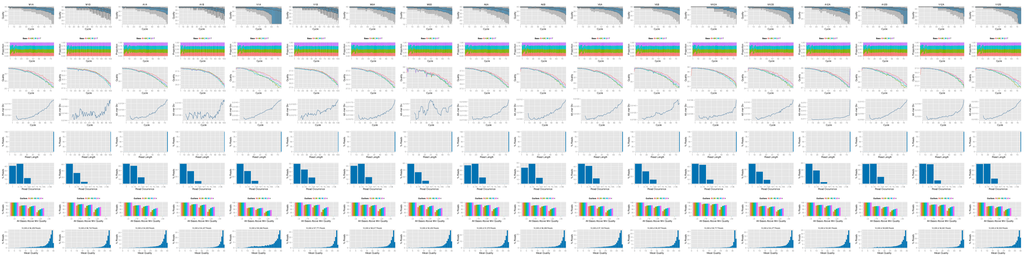

```r
appendStep(sal) <- LineWise(code = {
    fq_files <- getColumn(sal, "preprocessing", "targetsWF",
        column = 1)
    fqlist <- seeFastq(fastq = fq_files, batchsize = 10000, klength = 8)
    pdf("./results/fastqReport.pdf", height = 18, width = 4 *
        length(fqlist))
    seeFastqPlot(fqlist)
    dev.off()
}, step_name = "fastq_report", dependency = "preprocessing")
```

**Figure 1:** FASTQ quality report. To zoom in, right click image and open it in a separate browser tab.

## 3.3 Alignments

### 3.3.1 Read mapping with `HISAT2`

The following steps will demonstrate how to use the short read aligner `Hisat2` (Kim, Langmead, and Salzberg 2015). First, the `Hisat2` index needs to be created.

```r
appendStep(sal) <- SYSargsList(step_name = "hisat2_index", dir = FALSE,
    targets = NULL, wf_file = "hisat2/hisat2-index.cwl", input_file = "hisat2/hisat2-index.yml",
    dir_path = "param/cwl", dependency = "load_SPR")
```

### 3.3.2 `HISAT2` mapping

The parameter settings of the aligner are defined in the `workflow_hisat2-pe.cwl` and `workflow_hisat2-pe.yml` files. The following shows how to construct the corresponding *SYSargsList* object.

```r
appendStep(sal) <- SYSargsList(step_name = "hisat2_mapping",
    dir = TRUE, targets = "targetsPE.txt", wf_file = "workflow-hisat2/workflow_hisat2-pe.cwl",
    input_file = "workflow-hisat2/workflow_hisat2-pe.yml", dir_path = "param/cwl",
    inputvars = c(FileName1 = "_FASTQ_PATH1_", FileName2 = "_FASTQ_PATH2_",
        SampleName = "_SampleName_"), dependency = c("hisat2_index"))
```

To double-check the command line for each sample, please use the following:

```r
cmdlist(sal, step = "hisat2_mapping", targets = 1)
```

### 3.3.3 Read and alignment stats

The following provides an overview of the number of reads in each sample and how many of them aligned to the reference.

```r
appendStep(sal) <- LineWise(code = {
    fqpaths <- getColumn(sal, step = "hisat2_mapping", "targetsWF",
        column = "FileName1")
    bampaths <- getColumn(sal, step = "hisat2_mapping", "outfiles",
        column = "samtools_sort_bam")
    read_statsDF <- alignStats(args = bampaths, fqpaths = fqpaths,
        pairEnd = TRUE)
    write.table(read_statsDF, "results/alignStats.xls", row.names = FALSE,
        quote = FALSE, sep = "\t")
}, step_name = "align_stats", dependency = "hisat2_mapping")
```

## 3.4 Create symbolic links for viewing BAM files in IGV

The `symLink2bam` function creates symbolic links to view the BAM alignment files in a genome browser such as IGV without moving these large files to a local system. The corresponding URLs are written to a file with a path specified under `urlfile`, here `IGVurl.txt`. Please replace the directory and the user name.

```r
appendStep(sal) <- LineWise(code = {
    bampaths <- getColumn(sal, step = "hisat2_mapping", "outfiles",
        column = "samtools_sort_bam")
    symLink2bam(sysargs = bampaths, htmldir = c("~/.html/", "somedir/"),
        urlbase = "http://cluster.hpcc.ucr.edu/~tgirke/", urlfile = "./results/IGVurl.txt")
}, step_name = "bam_IGV", dependency = "hisat2_mapping", run_step = "optional")
```

## 3.5 Read distribution across genomic features

The `genFeatures` function generates a variety of feature types from `TxDb` objects using utilities provided by the `GenomicFeatures` package.

### 3.5.1 Obtain feature types

The first step is the generation of the feature type ranges based on annotations provided by a GFF file that can be transformed into a `TxDb` object. This includes ranges for mRNAs, exons, introns, UTRs, CDSs, miRNAs, rRNAs, tRNAs, promoter and intergenic regions. In addition, any number of custom annotations can be included in this routine.

```r
appendStep(sal) <- LineWise(code = {
    txdb <- suppressWarnings(makeTxDbFromGFF(file = "data/tair10.gff",
        format = "gff3", dataSource = "TAIR", organism = "Arabidopsis thaliana"))
    feat <- genFeatures(txdb, featuretype = "all", reduce_ranges = TRUE,
        upstream = 1000, downstream = 0, verbose = TRUE)
}, step_name = "genFeatures", dependency = "hisat2_mapping",
    run_step = "mandatory")
```

### 3.5.2 Count and plot reads of any length

The `featuretypeCounts` function counts how many reads in short read alignment files (BAM format) overlap with entire annotation categories. This utility is useful for analyzing the distribution of the read mappings across feature types, *e.g.* coding versus non-coding genes. By default the read counts are reported for the sense and antisense strand of each feature type separately. To minimize memory consumption, the BAM files are processed in a stream using utilities from the `Rsamtools` and `GenomicAlignment` packages. The counts can be reported for each read length separately or as a single value for reads of any length. Subsequently, the counting results can be plotted with the associated `plotfeaturetypeCounts` function.

The following generates and plots feature counts for any read length.

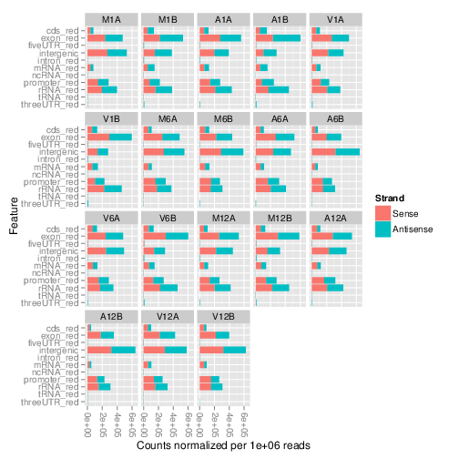

```r
appendStep(sal) <- LineWise(code = {
    outpaths <- getColumn(sal, step = "hisat2_mapping", "outfiles",
        column = "samtools_sort_bam")
    fc <- featuretypeCounts(bfl = BamFileList(outpaths, yieldSize = 50000),
        grl = feat, singleEnd = FALSE, readlength = NULL, type = "data.frame")
    p <- plotfeaturetypeCounts(x = fc, graphicsfile = "results/featureCounts.png",
        graphicsformat = "png", scales = "fixed", anyreadlength = TRUE,
        scale_length_val = NULL)
}, step_name = "featuretypeCounts", dependency = "genFeatures",
    run_step = "mandatory")
```

Figure 2: Read distribution plot across annotation features for any read length.

### 3.5.3 Count and plot reads of specific lengths

To determine the approximate read length of ribosome footprints in Ribo-Seq experiments, one can generate and plot the feature counts for specific read lengths separately. Typically, the most abundant read length obtained for translated features corresponds to the approximate footprint length occupied by the ribosomes.

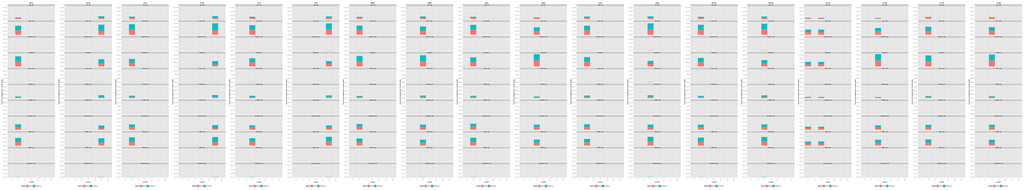

```r
appendStep(sal) <- LineWise(code = {
    fc2 <- featuretypeCounts(bfl = BamFileList(outpaths, yieldSize = 50000),
        grl = feat, singleEnd = TRUE, readlength = c(74:76, 99:102),
        type = "data.frame")
    p2 <- plotfeaturetypeCounts(x = fc2, graphicsfile = "results/featureCounts2.png",
        graphicsformat = "png", scales = "fixed", anyreadlength = FALSE,
        scale_length_val = NULL)
}, step_name = "featuretypeCounts_length", dependency = "featuretypeCounts",
    run_step = "mandatory")
```

Figure 3: Read distribution plot across annotation features for specific read lengths.

## 3.6 Adding custom features to workflow

### 3.6.1 Predicting uORFs in 5’ UTR regions

The function `predORF` can be used to identify open reading frames (ORFs) and coding sequences (CDSs) in DNA sequences provided as `DNAString` or `DNAStringSet` objects. The setting `mode='ORF'` returns continuous reading frames that begin with a start codon and end with a stop codon, while `mode='CDS'` returns continuous reading frames that do not need to begin or end with start or stop codons, respectively. Non-canonical start and stop condons are supported by allowing the user to provide any custom set of triplets under the `startcodon` and `stopcodon` arguments (`i.e.` non-ATG start codons). The argument `n` defines the maximum number of ORFs to return for each input sequence (*e.g.* `n=1` returns only the longest ORF). It also supports the identification of overlapping and nested ORFs. Alternatively, one can return all non-overlapping ORFs including the longest ORF for each input sequence with `n="all"` and `longest_disjoint=TRUE`.

```r
appendStep(sal) <- LineWise(code = {
    txdb <- suppressWarnings(makeTxDbFromGFF(file = "data/tair10.gff",
        format = "gff3", organism = "Arabidopsis"))
    futr <- fiveUTRsByTranscript(txdb, use.names = TRUE)
    dna <- extractTranscriptSeqs(FaFile("data/tair10.fasta"),
        futr)
    uorf <- predORF(dna, n = "all", mode = "orf", longest_disjoint = TRUE,
        strand = "sense")
}, step_name = "pred_ORF", dependency = "featuretypeCounts_length")
```

To use the predicted ORF ranges for expression analysis given genome alignments as input, it is necessary to scale them to the corresponding genome coordinates. The function `scaleRanges` does this by transforming the mappings of spliced features (query ranges) to their corresponding genome coordinates (subject ranges). The method accounts for introns in the subject ranges that are absent in the query ranges. The above uORFs predicted in the provided 5’ UTRs sequences using `predORF` are a typical use case for this application. These query ranges are given relative to the 5’ UTR sequences and `scaleRanges` will convert them to the corresponding genome coordinates. The resulting `GRangesList` object (here `grl_scaled`) can be directly used for read counting.

```r
appendStep(sal) <- LineWise(code = {
    grl_scaled <- scaleRanges(subject = futr, query = uorf, type = "uORF",
        verbose = TRUE)
    export.gff3(unlist(grl_scaled), "results/uorf.gff")
}, step_name = "scale_ranges", dependency = "pred_ORF")
```

To confirm the correctness of the obtained uORF ranges, one can parse their corresponding DNA sequences from the reference genome with the `getSeq` function and then translate them with the `translate` function into proteins. Typically, the returned protein sequences should start with a `M` (corresponding to start codon) and end with `*` (corresponding to stop codon). The following example does this for a single uORF containing three exons.

```r
appendStep(sal) <- LineWise(code = {
    translate(unlist(getSeq(FaFile("data/tair10.fasta"), grl_scaled[[7]])))
}, step_name = "translate", dependency = "scale_ranges")
```

### 3.6.2 Adding custom features to other feature types

If required custom feature ranges can be added to the standard features generated with the `genFeatures` function above. The following does this for the uORF ranges predicted with `predORF`.

```r
appendStep(sal) <- LineWise(code = {
    feat <- genFeatures(txdb, featuretype = "all", reduce_ranges = FALSE)
    feat <- c(feat, GRangesList(uORF = unlist(grl_scaled)))
}, step_name = "add_features", dependency = c("genFeatures",
    "scale_ranges"))
```

### 3.6.3 Predicting sORFs in intergenic regions

The following identifies continuous ORFs in intergenic regions. Note, `predORF` can only identify continuous ORFs in query sequences. The function does not identify and remove introns prior to the ORF prediction.

```r
appendStep(sal) <- LineWise(code = {
    feat <- genFeatures(txdb, featuretype = "intergenic", reduce_ranges = TRUE)
    intergenic <- feat$intergenic
    strand(intergenic) <- "+"
    dna <- getSeq(FaFile("data/tair10.fasta"), intergenic)
    names(dna) <- mcols(intergenic)$feature_by
    sorf <- suppressWarnings(predORF(dna, n = "all", mode = "orf",
        longest_disjoint = TRUE, strand = "both"))
    sorf <- sorf[width(sorf) > 60]  # Remove sORFs below length cutoff, here 60bp
    intergenic <- split(intergenic, mcols(intergenic)$feature_by)
    grl_scaled_intergenic <- scaleRanges(subject = intergenic,
        query = sorf, type = "sORF", verbose = TRUE)
    export.gff3(unlist(grl_scaled_intergenic), "sorf.gff")
    translate(getSeq(FaFile("data/tair10.fasta"), unlist(grl_scaled_intergenic)))
}, step_name = "pred_sORFs", dependency = c("add_features"))
```